# Workflow with fmcmc

George G. Vega Yon

April 19th, 2019

# Motivating example

We start by loading the dataset that the `mcmc` package includes. We will use the `logit` data set to obtain a posterior distribution of the model parameters using the `MCMC` function.

```r
library(fmcmc)
data(logit, package = "mcmc")
out <- glm(y ~ x1 + x2 + x3 + x4, data = logit, family = binomial, x = TRUE)
beta.init <- as.numeric(coefficients(out))
```

To use the Metropolis-Hastings MCMC algorithm, the function should be (in principle) the log unnormalized posterior. The following block of code, extracted from the `mcmc` package vignette “MCMC Package Example,” creates the function that we will be using:

```r
lupost_factory <- function(x, y) function(beta) {
    eta <- as.numeric(x %*% beta)
    logp <- ifelse(eta < 0, eta - log1p(exp(eta)), - log1p(exp(- eta)))
    logq <- ifelse(eta < 0, - log1p(exp(eta)), - eta - log1p(exp(- eta)))
    logl <- sum(logp[y == 1]) + sum(logq[y == 0])
    return(logl - sum(beta^2) / 8)
}

lupost <- lupost_factory(out$x, out$y)
```

```r
# to get reproducible results
set.seed(42)
out <- MCMC(
  initial = beta.init,
  fun     = lupost,
  nsteps  = 1e3
)
```

Since the resulting object is of class `mcmc` (from the `coda` R package), we can use all the functions included in `coda` for model diagnostics:

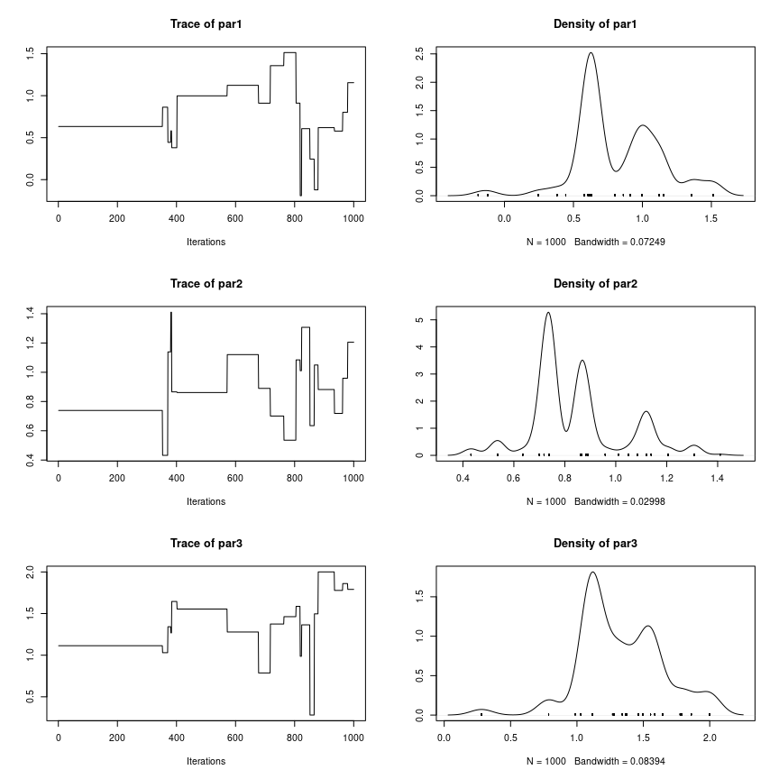

```r
library(coda)
plot(out[,1:3])
```

So this chain has very poor mixing, so let’s try again by using a smaller scale for the normal kernel proposal moving it from 1 (the default value) to .2:

```r
# to get reproducible results
set.seed(42)
out <- MCMC(
  initial = beta.init,
  fun     = lupost,
  nsteps  = 1e3,
  kernel  = kernel_normal(scale = .2)
)
```

The `kernel_normal`–the default kernel in the `MCMC` function–returns an object of class `fmcmc_kernel`. In principle, it consists of a list of two functions that are used by the `MCMC` routine: `proposal`, the proposal kernel function, and `logratio`, the function that returns the log of the Metropolis-Hastings ratio. We will talk more about `fmcmc_kernel` objects later. Now, let’s look at the first three variables of our model:

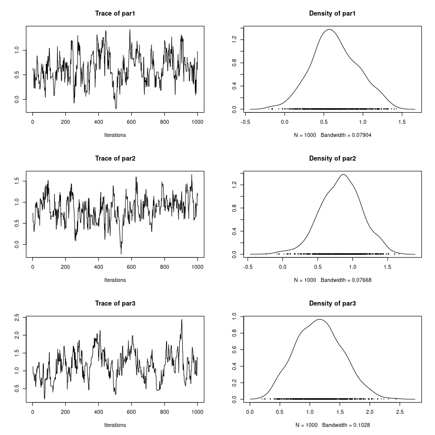

```r
plot(out[,1:3])
```

```r
# to get reproducible results
set.seed(42)
out <- MCMC(
  initial = beta.init,
  fun     = lupost,
  nsteps  = 1e4,
  kernel  = kernel_normal(scale = .2),
  conv_checker = convergence_geweke(200)
)
```

```
## Convergence has been reached with 200 steps. avg Geweke's Z: 1.1854. (200 final count of samples).
```

A bit better. As announced by `MCMC`, the `convergence_geweke` checker suggests that the chain reached a stationary state. With this in hand, we can now rerun the algorithm such that we start from the last couple of steps of the chain, this time, without convergence monitoring as it is no longer necessary.

We will increase the number of steps (sample size), use two chains using parallel computing, and add some thinning to reduce autocorrelation:

```r
# Now, we change the seed, so we get a different stream of
# pseudo random numbers
set.seed(112)

out_final <- MCMC(
  initial   = out,                       # Automagically takes the last 2 points
  fun       = lupost,
  nsteps    = 5e4,                       # Increasing the sample size
  kernel    = kernel_normal(scale = .2),
  thin      = 10,
  nchains   = 2L,                        # Running parallel chains
  multicore = TRUE                       # in parallel.
  )
```

Notice that, instead of specifying the starting points for each chain, we passed the `out` object to `initial`. By default, if `initial` is of class `mcmc`, `MCMC` will take the last `nchains` points from the chain as starting point for the new sequence. If `initial` is of class `mcmc.list`, the number of chains in `initial` must match the `nchains` parameter. We now see that the output posterior distribution appears to be stationary

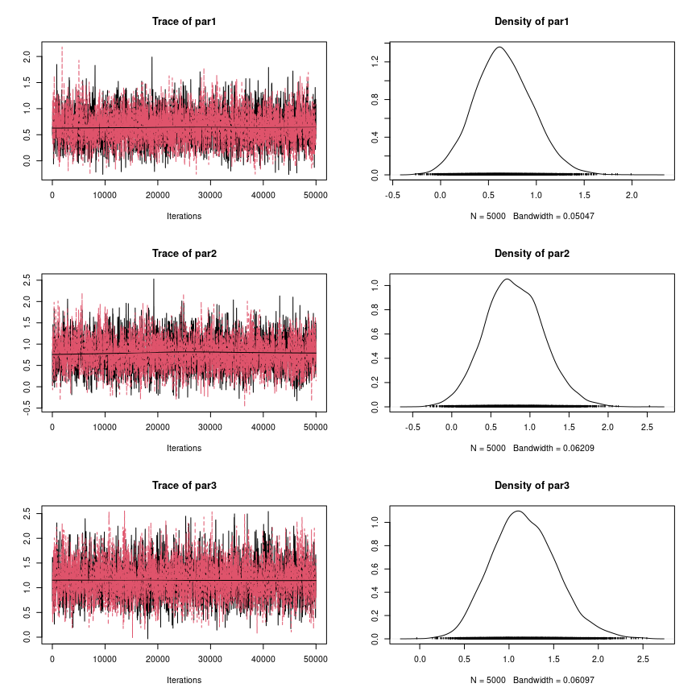

```r
plot(out_final[, 1:3])
```

```r
summary(out_final[, 1:3])
```

```
##
## Iterations = 10:50000
## Thinning interval = 10
## Number of chains = 2
## Sample size per chain = 5000
##
## 1. Empirical mean and standard deviation for each variable,
##    plus standard error of the mean:
##
##        Mean     SD Naive SE Time-series SE
## par1 0.6575 0.3005 0.003005       0.004844
## par2 0.7998 0.3696 0.003696       0.006680
## par3 1.1719 0.3629 0.003629       0.006884
##
## 2. Quantiles for each variable:
##
##        2.5%    25%    50%    75% 97.5%
## par1 0.0924 0.4509 0.6445 0.8535 1.275
## par2 0.1084 0.5457 0.7846 1.0470 1.560
## par3 0.5181 0.9193 1.1533 1.4079 1.939
```

# Reusing fmcmc_kernel objects

`fmcmc_kernel` objects are environments that are passed to the `MCMC` function. While the `MCMC` function only returns the `mcmc` class object (as defined in the `coda` package), users can exploit the fact that the kernel objects are environments to reuse them or inspect them once the `MCMC` function returns. For example, `fmcmc_kernel` objects can be useful with adaptive kernels as users can review the covariance structure or other components.

```r
khaario <- kernel_adapt(freq = 1, warmup = 500)
```

The MCMC function will update the kernel at every step (`freq = 1`), and the adaptation will start from step 500 (`warmup = 500`). We can see that some of its components haven’t been initialized or have a default starting value before the call of the `MCMC` function:

```r
# Number of iterations (absolute count, starts in 0)
khaario$abs_iter
```

```
## [1] 0
```

```r
# Variance covariance matrix (is empty... for now)
khaario$Sigma
```

[output not shown]

Let’s see how it works:

```r
set.seed(12)

out_haario_1 <- MCMC(
  initial   = out,
  fun       = lupost,
  nsteps    = 1000,    # We will only run the chain for 100 steps
  kernel    = khaario, # We passed the predefined kernel
  thin      = 1,       # No thining here
  nchains   = 1L,      # A single chain
  multicore = FALSE    # Running in serial
  )
```

Let’s inspect the output and mark when the adaptation starts:

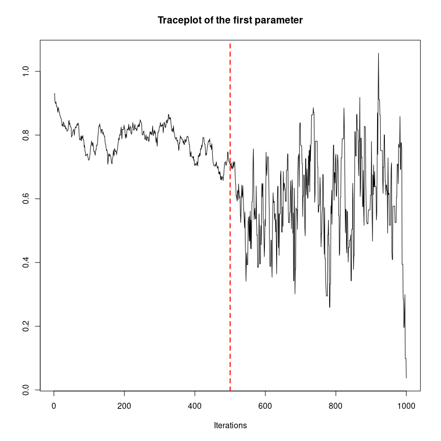

```r
traceplot(out_haario_1[,1], main = "Traceplot of the first parameter")
abline(v = 500, col = "red", lwd = 2, lty=2)
```

If we look at the `khaario` kernel, the `fmcmc_kernel` object, we can see that things changed from the first time we ran it

```r
# Number of iterations (absolute count, the counts equal the number of steps)
khaario$abs_iter
```

```
## [1] 999
```

```r
# Variance covariance matrix (now is not empty)
(Sigma1 <- khaario$Sigma)
```

```
##              [,1]          [,2]         [,3]          [,4]          [,5]
## [1,]  0.018860119 -3.332717e-03 -0.008727212 -0.0325079868  6.073619e-03
## [2,] -0.003332717  1.329341e-02  0.014426084 -0.0004692044 -4.190311e-05
## [3,] -0.008727212  1.442608e-02  0.024491648  0.0098554654 -1.308236e-03
## [4,] -0.032507987 -4.692044e-04  0.009855465  0.1258067668 -1.195835e-02
## [5,]  0.006073619 -4.190311e-05 -0.001308236 -0.0119583520  1.953713e-02
```

If we re-run the chain, using as starting point the last step of the first run, we can also continue using the kernel object:

```r
out_haario_2 <- MCMC(
  initial   = out_haario_1,
  fun       = lupost,
  nsteps    = 2000,    # We will only run the chain for 2000 steps now
  kernel    = khaario, # Same as before, same kernel.
  thin      = 1,
  nchains   = 1L,
  multicore = FALSE,
  seed      = 555      # We can also specify the seed in the MCMC function
  )
```

Let’s see again how does everything looks like:

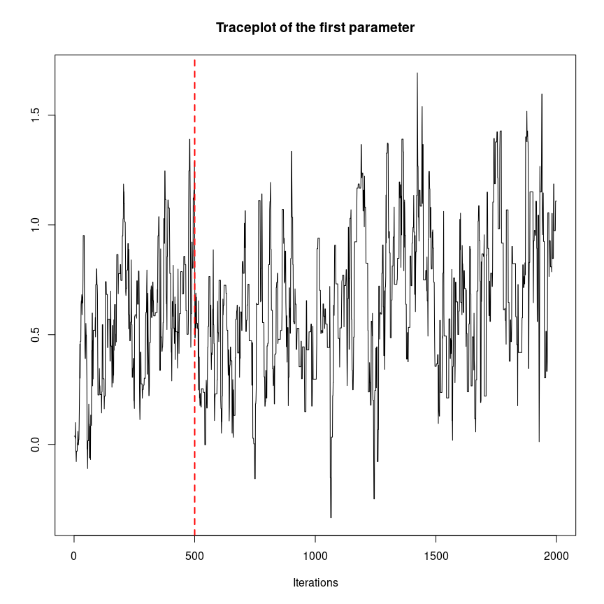

```r
traceplot(out_haario_2[,1], main = "Traceplot of the first parameter")
abline(v = 500, col = "red", lwd = 2, lty=2)
```

As shown in the plot, since the warmup period already passed for the kernel object, the adaptation process is happening at every step, so we don’t see a big break at step 500 as before. Let’s see the counts and the covariance matrix and compare it with the previous one:

```r
# Number of iterations (absolute count, the counts equal the number of steps)
# This will have 1000 (first run) + 2000 (second run) steps
khaario$abs_iter
```

```
## [1] 2998
```

```r
# Variance covariance matrix (now is not empty)
(Sigma2 <- khaario$Sigma)
```

```
##             [,1]        [,2]         [,3]        [,4]         [,5]
## [1,]  0.07830456  0.00649061  0.035844799 -0.01054921  0.023544929
## [2,]  0.00649061  0.10794138 -0.016443314 -0.02806675 -0.020701377
## [3,]  0.03584480 -0.01644331  0.108915397  0.03737444  0.001673125
## [4,] -0.01054921 -0.02806675  0.037374444  0.19827548 -0.023571157
## [5,]  0.02354493 -0.02070138  0.001673125 -0.02357116  0.111933531
```

```r
# How different are these?
Sigma1 - Sigma2
```

```
##              [,1]         [,2]         [,3]        [,4]         [,5]
## [1,] -0.059444446 -0.009823328 -0.044572011 -0.02195878 -0.017471310
## [2,] -0.009823328 -0.094647970  0.030869398  0.02759754  0.020659473
## [3,] -0.044572011  0.030869398 -0.084423749 -0.02751898 -0.002981361
## [4,] -0.021958782  0.027597543 -0.027518978 -0.07246872  0.011612805
## [5,] -0.017471310  0.020659473 -0.002981361  0.01161280 -0.092396405
```

Things have changed since the last time we used the kernel, as expected. Kernel objects in the `fmcmc` package can also be used with multiple chains and in parallel. The `MCMC` function is smart enough to create independent copies of `fmcmc_kernel` objects when running multiple chains, and keep the original kernel objects up-to-date even when using multiple cores to run `MCMC`. For more technical details on how `fmcmc_kernel` objects work see the manual `?fmcmc_kernel` or the vignette “User-defined kernels” included in the package `vignette("user-defined-kernels", package = "fmcmc")`.

# Accessing other elements of the chain

In some situations, you may want to access the computed unnormalized log-posterior probabilities, the states proposed by the kernel, or other process components. In those cases, the functions with the prefix `get_*` can help you.

Starting version 0.5-0, we replaced the family of functions `last_*` with `get_*`; a re-design of this “memory” component that gives users access to data generated during the Markov process. After each run of the `MCMC` function, information regarding the last execution is stored in the environment `MCMC_OUTPUT`.

If you wanted to look at the logposterior of the last call and proposed states, you can do the following:

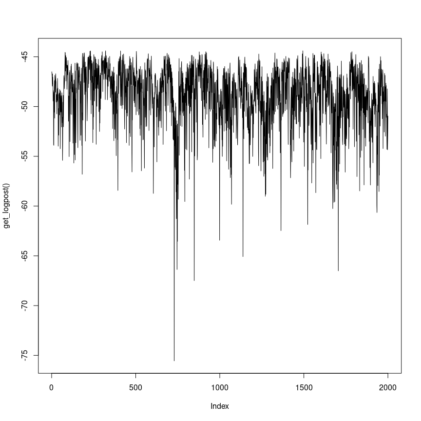

```r
plot(get_logpost(), type="l")
```

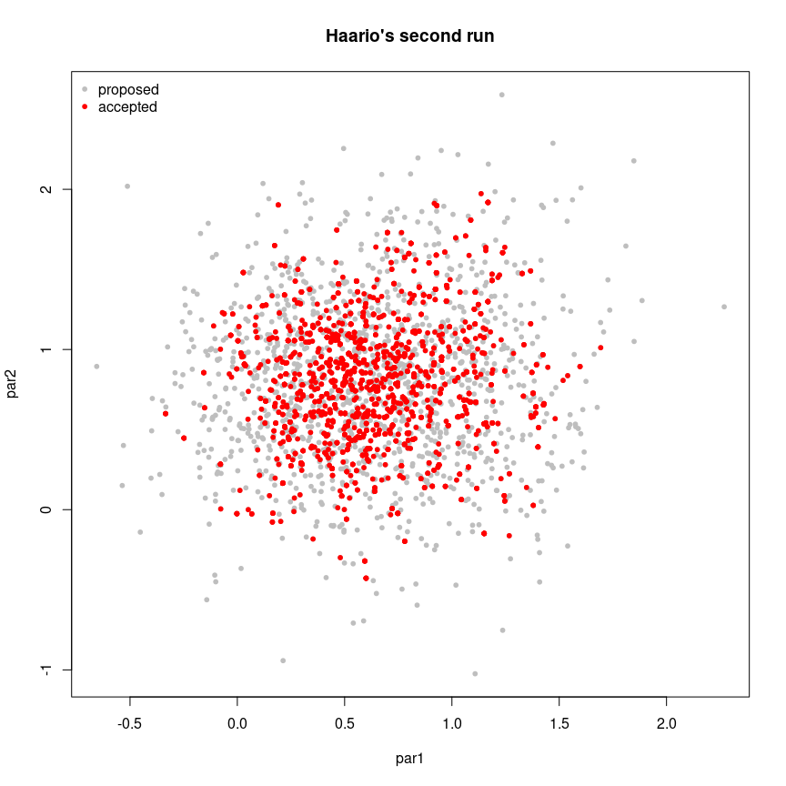

```r
# Pretty figure showing proposed and accepted
plot(
  get_draws()[,1:2], pch = 20, col = "gray",
  main = "Haario's second run"
  )
points(out_haario_2[,1:2], col = "red", pch = 20)
legend(
  "topleft", legend = c("proposed", "accepted"),
  col = c("gray", "red"),
  pch = 20,
  bty = "n"
)
```

The `MCMC_OUTPUT` environment also contains the arguments passed to `MCMC()`:

```r
get_initial()
```

```
## Markov Chain Monte Carlo (MCMC) output:
## Start = 1000
## End = 1000
## Thinning interval = 1
##            par1      par2     par3      par4      par5
## 1000 0.03743564 0.8992076 0.726668 0.3899513 0.4633549
```

```r
get_fun()
```

```
## function(beta) {
##     eta <- as.numeric(x %*% beta)
##     logp <- ifelse(eta < 0, eta - log1p(exp(eta)), - log1p(exp(- eta)))
##     logq <- ifelse(eta < 0, - log1p(exp(eta)), - eta - log1p(exp(- eta)))
##     logl <- sum(logp[y == 1]) + sum(logq[y == 0])
##     return(logl - sum(beta^2) / 8)
## }
## <bytecode: 0x5649153b13c0>
## <environment: 0x56491458fe48>
```

```r
get_kernel()
```

```
##
## An environment of class fmcmc_kernel:
##
## Ik :  num [1:5, 1:5] 1e-04 0e+00 0e+00 0e+00 0e+00 0e+00 1e-04 0e+00 0e+00 0e+00 ...
## Mean_t_prev :  num [1, 1:5] 0.654 0.829 1.103 0.299 0.75
## Sd :  num 1.15
## Sigma :  num [1:5, 1:5] 0.0783 0.00649 0.03584 -0.01055 0.02354 ...
## abs_iter :  int 2998
## bw :  int 0
## eps :  num 1e-04
## fixed :  logi [1:5] FALSE FALSE FALSE FALSE FALSE
## freq :  num 1
## k :  int 5
## lb :  num [1:5] -1.8e+308 -1.8e+308 -1.8e+308 -1.8e+308 -1.8e+308
## logratio : function (env)
## mu :  num [1:5] 0 0 0 0 0
## proposal : function (env)
## ub :  num [1:5] 1.8e+308 1.8e+308 1.8e+308 1.8e+308 1.8e+308
## until :  num Inf
## warmup :  num 500
## which. :  int [1:5] 1 2 3 4 5
```